# stats-slide-4

Sudev

Wednesday, February 25, 2015

## We will talk about

- Mean
- Median
- Variance
- Standard Deviation
- Correlation
- Associative Analysis
- A tutorial on [boxplots](http://msenux.redwoods.edu/math/R/boxplot.php), amazing stuff.

# Measure of location

- **Mean** - is the average of the datapoints
- **Median** - is the 50th percentile.  
  [Calculating median](http://mathworld.wolfram.com/StatisticalMedian.html)  
  *Note* - Percentile is different from percentage.
- Terminology 1st, 2nd and 3rd quartiles are the 25th, 50th and 75th percentiles respectively.

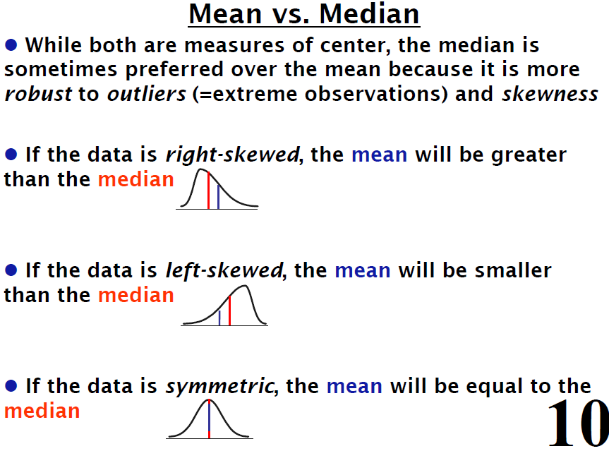

# Measure of Spread

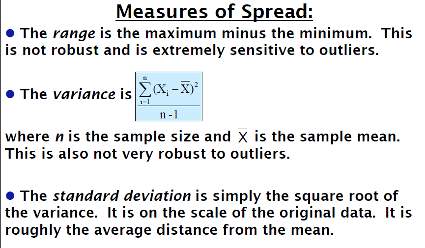

Standard deviation is the average distance from the mean value.

```r
x <- c(2, 10, 22, 43, 18)
mean(x)
```

```
## [1] 19
```

```r
median(x)
```

```
## [1] 18
```

```r
sd(x)
```

```
## [1] 15.45962
```

### Measure of Association

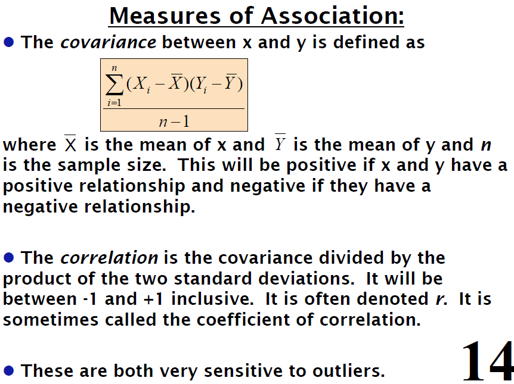

- Correlation
- [Dont know correlation ?](https://www.mathsisfun.com/data/correlation.html)

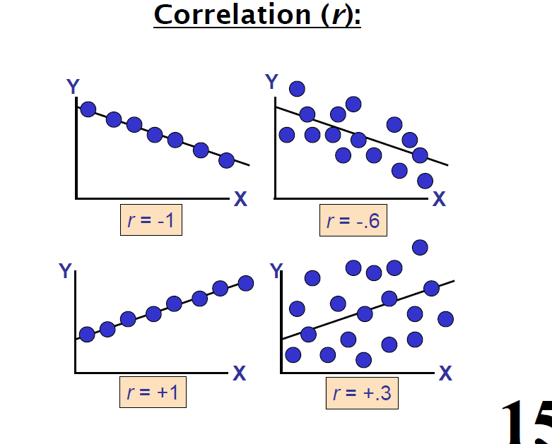

```r
# Creating a sample correlated X and Y vectors
x <- 1:10
y <- (x+x) + 15
cor(x,y)
```

```
## [1] 1
```

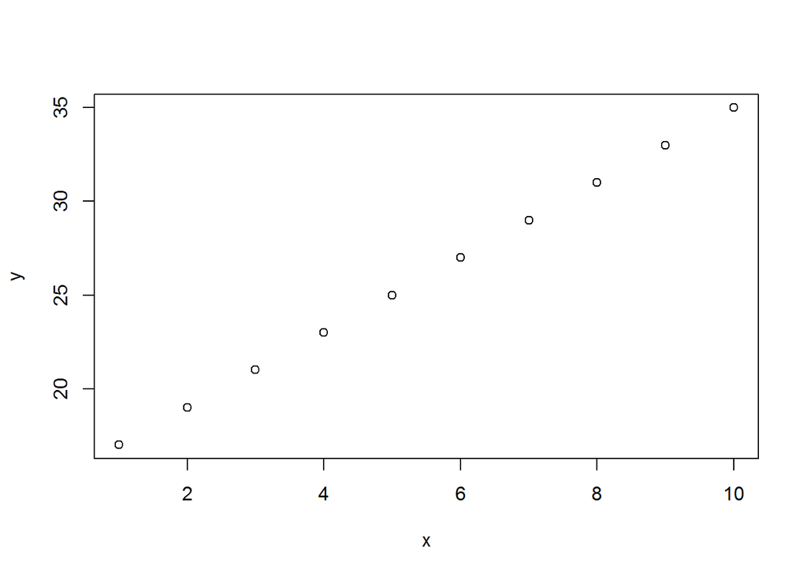

```r
plot(x, y)
```

```r
# runif function generates random numbers
# Correlation for random sample vectors X and Y
x <- runif(100)
y <- runif(100)
cor(x,y)
```

```
## [1] -0.03876354
```

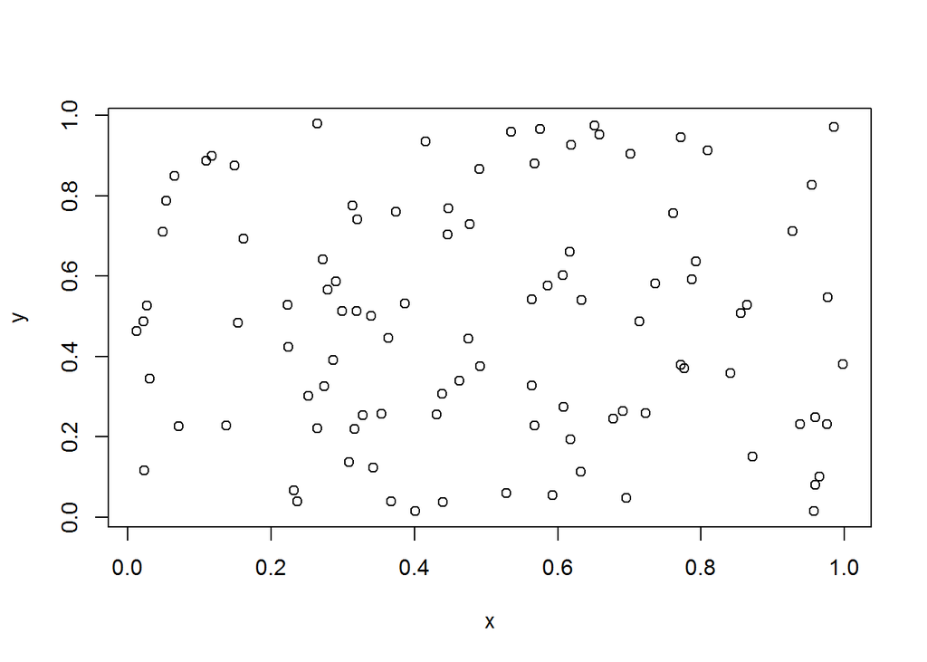

```r
plot(x, y)
```

- The correlation measure helps you decide the features for Kmeans sort of algorithms.

## Association Analysis

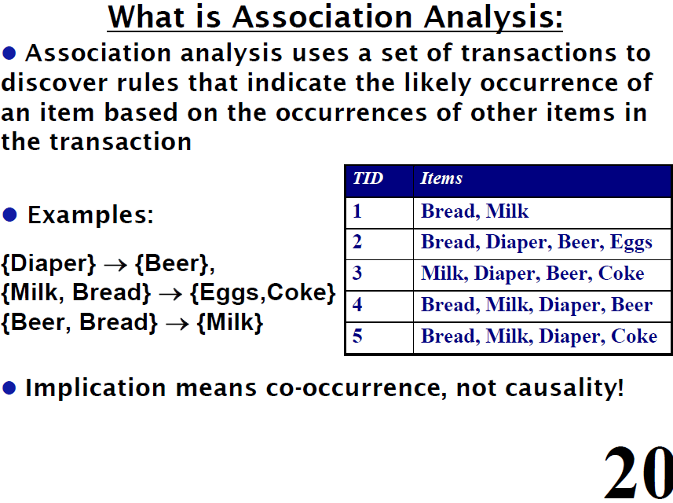

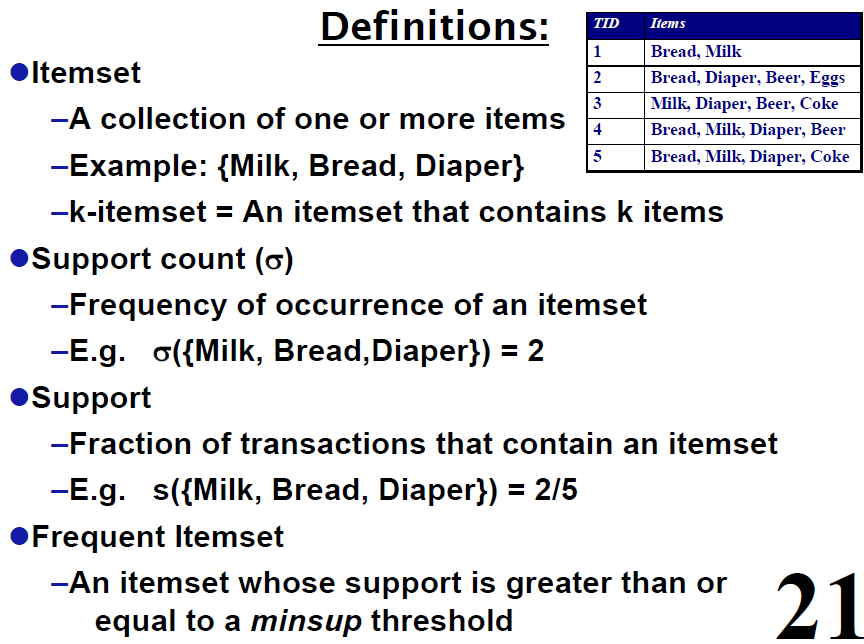

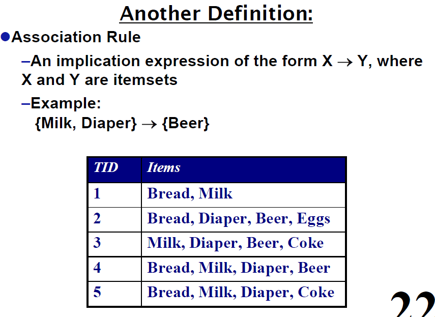

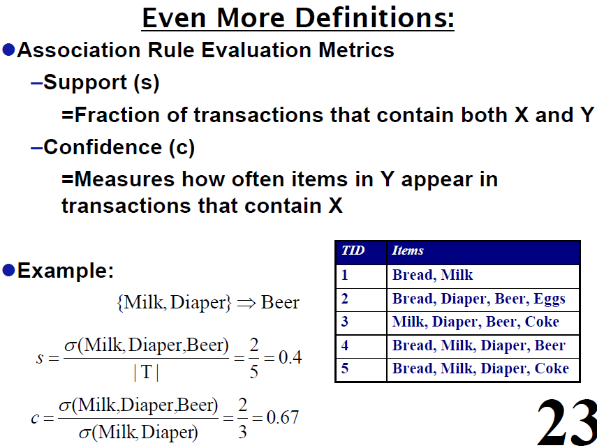

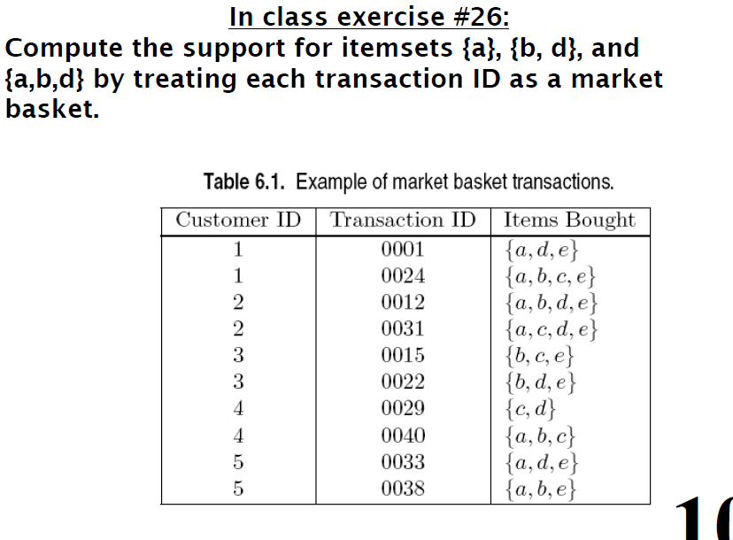

```r
# Entering the values
customer_id <- c(1, 1, 2, 2, 3, 3, 4, 4, 5, 5)
trans_id <- c(0001, 0024, 0012, 0031, 0015, 0022, 0029, 0040, 0033, 0038)
items_bought <- list( c("a", "d", "e"), c("a","b","c","e"), c("a","b","d","e"), c("a","c","d","e"), c("b","c","e"), c("b","d","e"), c("c","d"), c("a", "b", "C"), c("a", "d", "e"), c("a","b","c"))

# creating a named list for support and confidence
support = list()
confidence = list()
for (item in c("a", "b", "c", "d", "e"))
{
  count = 0
  for (i in 1:length(items_bought)){
   if ( item %in% items_bought[[i]] ) {
     count = count + 1
    }
  }
  support[item] = count
}
support
```

```
## $a
## [1] 7
##
## $b
## [1] 6
##
## $c
## [1] 5
##
## $d
## [1] 6
##
## $e
## [1] 7
```

```r
confidence <- sapply(support, function(x){ as.numeric(x[[1]] / 10) })
confidence
```

```
##   a   b   c   d   e
## 0.7 0.6 0.5 0.6 0.7
```

Solution:

Q1. The confidence for associative rule `{b, d} -> {a}`

S(a) = 7 / 10  
s(b, d) = 2 / 10  
s(a, b, d) = 1 / 10 s((b,d) -> (a)) = 1 / 10

C((b,d) -> (a) = S(a, b, d) / S(b, d) = (1 / 10) / (2 / 10) = 0.5

Q2. The confidence for associative rule `{a} -> {b, d}`  
Similarly,  
S(a -> (b,d)) = 1 / 10  
C(a -> (b, d)) = 1/ 7 = 0.14

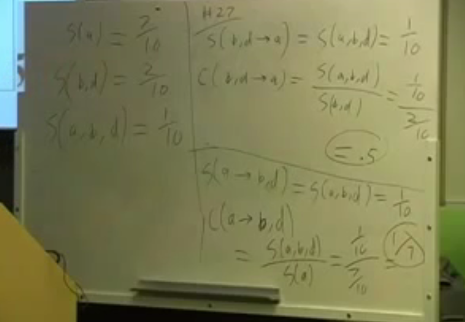

**Note** : Here we did all the analysis treating each transaction as a basket, we can also treat each customers as baskets ( i.e to club all the transaction of a customer and make it a basket). Try doing the same problem considering each customer as a basket.

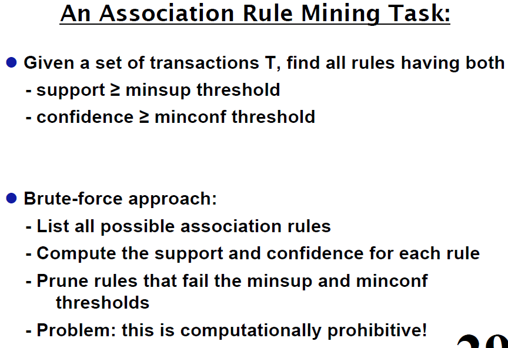

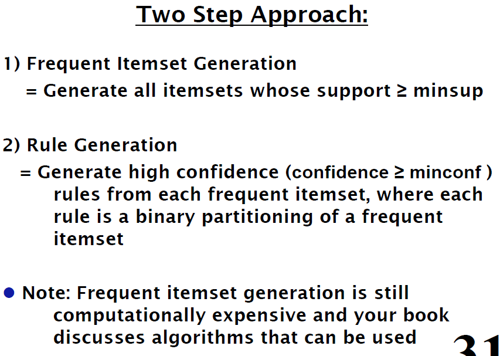

To know more about [market basket analysis](http://en.wikipedia.org/wiki/Affinity_analysis), read through the example scenarios.

# Courtesy

- Shamelesly copied form here and there + my examples. Mainly Stats 202 + Analytics Edge(edx).
- Created using Markdown + [Knitr](http://yihui.name/knitr/)